# dapR2: Week 2 Quiz

Tom Booth

14/09/2020

# Lecture 2.1: Best line quiz

## Question 1

Which colour line is the best fit to the data (points)?

1. Black
2. Red
3. Blue
4. Green

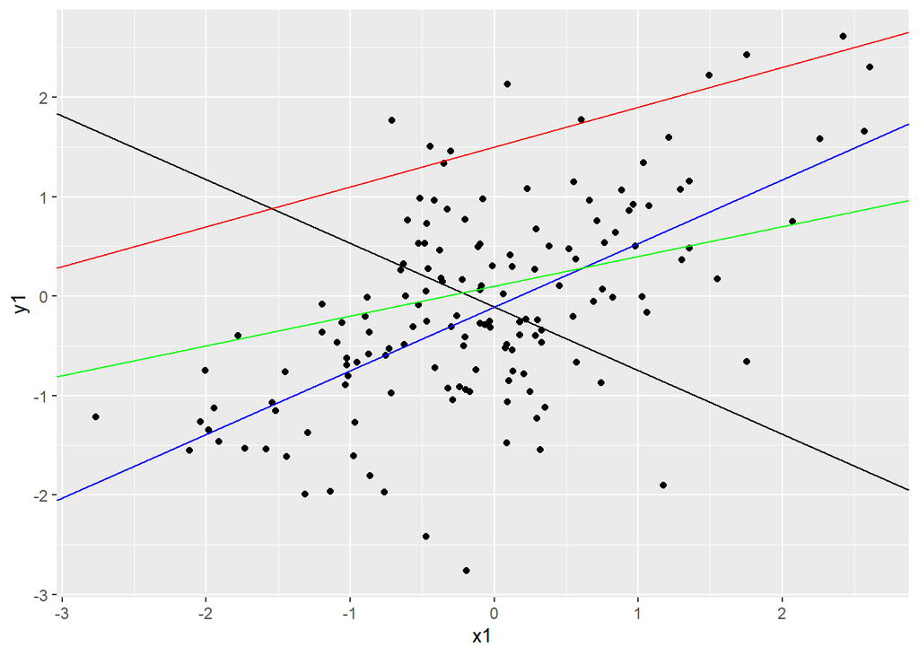

## Question 2

Which colour line is the best fit to the data (points)?

1. Black
2. Red
3. Blue
4. Green

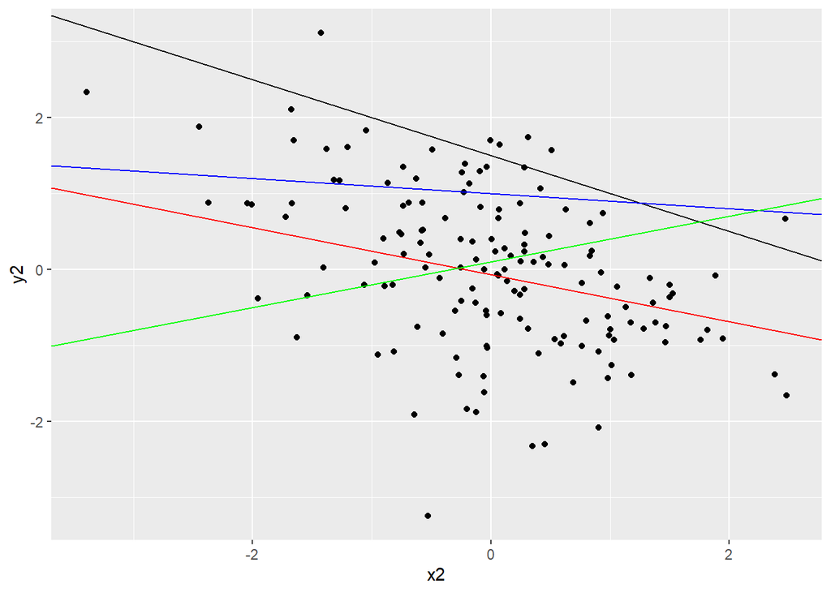

## Question 3

Which colour line is the best fit to the data (points)?

1. Black
2. Red
3. Blue
4. Green

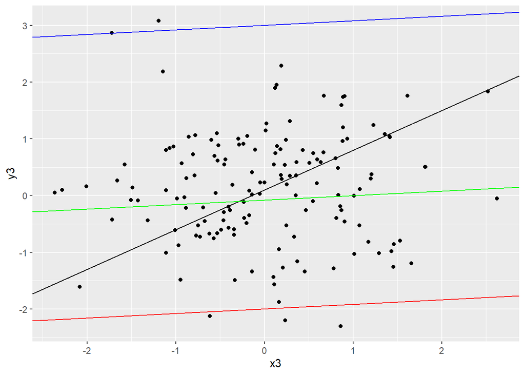

# Lecture 2.4: Interpretation of coefficients

## Question 1

I conduct a study where I measure the time it takes (in minutes) for a participant to complete a task, where the score for the task is the number of errors they make. My outcome measure is errors, and my predictor is time. I get the following results:

```
##
## Call:
## lm(formula = error ~ time, data = res)
##
## Residuals:
##     Min      1Q  Median      3Q     Max
## -3.4879 -0.5574  0.0105  0.5807  2.4545
##
## Coefficients:
##              Estimate Std. Error t value Pr(>|t|)
## (Intercept) -0.002032   0.076741  -0.026    0.979
## time        -0.462466   0.075970  -6.087  9.4e-09 ***
## ---
## Signif. codes:  0 '***' 0.001 '**' 0.01 '*' 0.05 '.' 0.1 ' ' 1
##
## Residual standard error: 0.9399 on 148 degrees of freedom
## Multiple R-squared:  0.2002, Adjusted R-squared:  0.1948
## F-statistic: 37.06 on 1 and 148 DF,  p-value: 9.399e-09
```

Write an interpretation of both the intercept and the coefficient for time.

## Question 2

A second set of researchers runs the same study, and conducts the same analysis. There results are shown below:

```
##
## Call:
## lm(formula = error ~ time, data = res)
##
## Residuals:
##      Min       1Q   Median       3Q      Max
## -2.58952 -0.48786  0.00414  0.45243  2.24994
##
## Coefficients:
##             Estimate Std. Error t value Pr(>|t|)
## (Intercept) -0.05717    0.06849  -0.835    0.405
## time         0.60112    0.06979   8.614 9.77e-15 ***
## ---
## Signif. codes:  0 '***' 0.001 '**' 0.01 '*' 0.05 '.' 0.1 ' ' 1
##
## Residual standard error: 0.8346 on 148 degrees of freedom
## Multiple R-squared:  0.3339, Adjusted R-squared:  0.3294
## F-statistic: 74.19 on 1 and 148 DF,  p-value: 9.771e-15
```

Write an interpretation of both the intercept and the coefficient for time.

How do the results from question 1 and question 2 differ? Which results make most sense given the variables measured?

# Lecture 2.5: Null distributions and SE

## Just one question….

The standard error is what?

1. variance of the normal distribution
2. standard deviation of the predictor
3. standard deviation of the sampling distribution
4. variance of the sampling distribution

If this questions seems like jibberish, before continuing, go back to week 1 materials and look again at the recap material on sampling and hypothesis testing. Note down any questions, and come to office hours to chat them over.